# Cross-border ANOVA and response structure

Current revised grid · scenarios, regional setups and external closures

## What is compared

The current results tag is **20261012_c79**. Twelve interventions (HH-Food, HH-Energy, HH-Wood, Gov-Plastics, Int-Wood, Int-Pulp, Int-Plastics, Int-Metal, Int-Glass, Int-Cement, Int-Energy, Int-Food; presentation numbers sc1–sc12, D-51) are crossed with two regional setups, EU/RoW and North/South, and four external closures: gold, fiat, expenditure-adjusting OPENFIXG and quasi-float. Each intervention is measured against its own arm’s baseline, as the mean over t = 79..100, one cycle of the baseline accelerator (D-65). Inv-Construction, Inv-Metal, Int-Construction and Inv-Recycling, and the OPENFLEX diagnostic, are excluded.

The analysis retains signed responses in both regions across activity, fiscal, external, distributional, financial and ecological outcome blocks. Coordinates are standardized, and the six outcome blocks are weighted equally. A share below is a share of weighted response variation across this declared finite grid, rather than a causal contribution to one trajectory.

## Readable scenario and observation codes

Use **channel–material–closure–setup**: for example, `HH-Food-OPENFIX-gold-NS` or `Int-Metal-OPENFIXG-EU-RoW`. HH means household consumption, Gov government consumption, Inv firm investment, and Int intermediate production. NS is North/South; EU-RoW is EU/rest of world. Gold and fiat remain explicit because OPENFIX alone would be ambiguous. HH and Int are alternative intervention channels; the material name identifies the substitution.

The submitted paper’s material-first abbreviations remain aliases; no simulation IDs or experiments are changed.

| Code | Submitted_alias | In_current_grid |
| --- | --- | --- |
| HH-Food | Food-HH | Yes |
| HH-Energy | Enrg-HH | Yes |
| HH-Wood | Wood-HH | Yes |
| Gov-Plastics | Plst-Gov | Yes |
| Inv-Construction | Cnst-FD | No — construction excluded |
| Inv-Metal | Mtl-FD | No — construction excluded |
| Int-Wood | Wood-Int | Yes |
| Int-Pulp | Pulp-Int | Yes |
| Int-Plastics | Plst-Int | Yes |
| Int-Metal | Mtl-Int | Yes |
| Int-Glass | Glss-Int | Yes |
| Int-Cement | Cmnt-Int | Yes |
| Int-Energy | Enrg-Int | Yes |
| Int-Construction | Cnst-Int | No — construction excluded |
| Inv-Recycling | NA | No — construction excluded |
| Int-Food | NA | Yes |

## Variables and response units

The pooled analysis studies **37 variables in each region: 74 coordinates**. A scenario profile keeps the eight configurations separately, giving 592 possible coordinates; 578 remain after dropping constant/nonfinite coordinates. Both representations standardize coordinates and give the six outcome blocks equal weight. Correlated and accounting-related coordinates are retained, so these are not 74 independent economic mechanisms.

|  | Block | Variables |
| --- | --- | --- |
| Real activity | Real activity | Total Real Consumption (c); Value Added (va); Gross Output (go); Real Investment in Fixed Capital (id); Nominal Output (y); Final Demand in Real Terms (fd) |
| Fiscal | Fiscal | Government Deficit (gdef); Tax Payments (t); Government Spending (g); Government Debt (b_s); Debt to GDP Ratio (debt_gdp) |
| External | External | Real Final Imports (imp); Real Final Exports (rex); Current Account Balance (cab); Trade Balance (tb) |
| Labour and distribution | Labour and distribution | Employment (n); Female Employment (nf); Profit Share of Disposable Income (shp); Wage Share of Disposable Income (shw); Wage Bill (wb); Disposable Income (yd); Worker Disposable Income (ydw); Capitali… |
| Finance and wealth | Finance and wealth | Household Demand for Personal Loans (lh); Corporate Demand for Bank Loans (lf); Net Household Wealth (v); Fixed Capital Stock (k); Corporate Profit (f_f) |
| Ecological | Ecological | Production of Material Goods (x_mat); Land Used (land); Extraction of Matter (mat); Recycled Matter (rec); Annual CO2 Emissions (emis); Waste (wa); Water Used (water); CO2 Concentration (co2_cum) |

Most measurements are percentage changes from the matching baseline. Current account, trade balance and government deficit are level differences divided by the region’s baseline value added, multiplied by 100. Wage/profit shares and debt/GDP use percentage-point differences; functional inequality uses 100 times its index difference. `co2_cum` is the catalogue’s CO₂-concentration stock measure, distinct from annual emissions. Employment and female employment measure labour demand; wage/profit income shares and class disposable incomes measure functional distribution rather than a household income-distribution Gini.

## Factorial decomposition

For each response coordinate, the complete factorial model separates scenario, setup and closure effects and all their interactions:

$$\begin{aligned}y_{sac}=\mu&+S_s+A_a+C_c\\&+(SA)_{sa}+(SC)_{sc}\\&+(AC)_{ac}+(SAC)_{sac}.\end{aligned}$$

The full 12 × 2 × 4 grid has 96 observations and 95 non-intercept degrees of freedom. There are no residual degrees of freedom. These ANOVA sums of squares are descriptive; they do not provide inferential F-tests or p-values.

| term | df | weighted_sum_of_squares | share_percent |
| --- | --- | --- | --- |
| scenario | 11 | 344.614195 | 60.458631 |
| setup | 1 | 8.773433 | 1.539199 |
| closure | 3 | 2.285001 | 0.400877 |
| scenario:setup | 11 | 103.365680 | 18.134330 |
| scenario:closure | 33 | 45.087693 | 7.910121 |
| setup:closure | 3 | 3.142624 | 0.551337 |
| scenario:setup:closure | 33 | 62.731374 | 11.005504 |

Scenario differences account for **60.46%** of weighted variation. Scenario × setup accounts for **18.13%**, scenario × closure for **7.91%**, and the three-way interaction for **11.01%**. Small standalone setup and closure shares do not imply that these dimensions are unimportant: their effects depend substantially on the intervention.

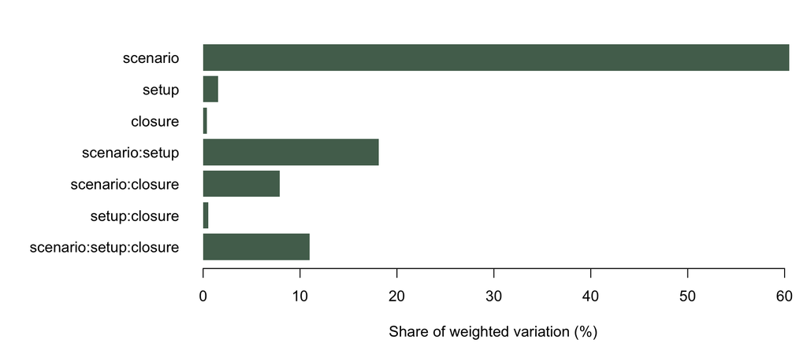

Shares of equally block-weighted standardized response variation in the current finite grid.

## Response grouping and sensitivity

Clustering groups observations by the geometry of their signed response vectors. It does not identify separate economic mechanisms. The selected number of groups changes with the permitted search range and minimum group size:

| cohort | criterion | k | silhouette | singletons | smallest_cluster |
| --- | --- | --- | --- | --- | --- |
| pooled | k 2 to 8 | 4 | 0.450301 | 0 | 4 |
| pooled | k 2 to 20 | 16 | 0.575362 | 4 | 1 |
| pooled | all nonsaturated cuts | 33 | 0.639517 | 14 | 1 |
| pooled | minimum group size 2 | 4 | 0.450301 | 0 | 4 |
| profiles | k 2 to 8 | 2 | 0.366754 | 0 | 3 |
| profiles | k 2 to 20 | 2 | 0.366754 | 0 | 3 |
| profiles | all nonsaturated cuts | 2 | 0.366754 | 0 | 3 |
| profiles | minimum group size 2 | 2 | 0.366754 | 0 | 3 |

The pooled 4-group cut is selected over k=2…8. Wider searches or excluding singleton groups select different cuts. Scenario-profile grouping keeps the eight setup/closure configurations in separate coordinates. Search ranges, features, linkage and accounting correlations qualify the interpretation of all groups.

## What the clustering is saying in scenario names

There are two clustering objects. **Pooled clustering** compares 96 individual scenario × closure × setup observations. Its selected 4-group cut is a descriptive partition; the membership table below gives the actual intervention and configuration mix. It is not a set of policy mechanisms.

| Group | Observations | Scenario_codes | Configurations |
| --- | --- | --- | --- |
| 1 | 64 | HH-Food, HH-Wood, Gov-Plastics, Int-Wood, Int-Pulp, Int-Plastics, Int-Glass, Int-Cement, Int-Food | Mixed responses across setups and closures; inspect the membership table below |
| 2 | 20 | HH-Energy, Int-Metal, Int-Energy | HH-Energy and Int-Energy in all eight arms; Int-Metal in the four EU/RoW arms |
| 3 | 8 | HH-Food, Int-Food | Mixed responses across setups and closures; inspect the membership table below |
| 4 | 4 | Int-Metal | Mixed responses across setups and closures; inspect the membership table below |

**Scenario-profile clustering** compares twelve interventions, preserving all eight configurations in separate coordinates. Its selected 2-group cut is another descriptive partition. Inspect the tree and membership table for its current members; the grouping is sensitive to the distance, linkage and feature set.

## Hierarchical clustering: named branches and regime fingerprints

Leaves Regional setup Distance Groups 2Highlight

Select a named leaf or regime tile to inspect it. Highlighting preserves the full hierarchy.

### Reading this tree

#### Cut by cut

Each cut is a merge of the tree read from the root down: cut j takes the tree from j to j + 1 groups. Cuts that the current “Groups” setting has made are in full colour, deeper ones are greyed. Regime counts are the value-added rule’s tiles on each side (one per setup × closure configuration). “What separates them” lists the four responses whose standardised means differ most between the two sides, with each side’s median raw response averaged over t = 79..100 (one cycle) over its scenarios and configurations.

### How well supported is this cut?

**Method**

**Tree.** Rows are the leaves (scenarios, or individual observations); columns are their responses averaged over t = 79..100, each standardised over the rows and divided by the square root of the number of columns in its outcome block, so the six blocks (real activity, fiscal, external, labour and distribution, finance and wealth, ecological) weigh equally. The tree is agglomerative: it starts with every leaf alone and, at each step, merges the two groups whose union increases the total within-group sum of squared distances the least (Ward’s criterion, in the “D2” form that works on Euclidean distances). The merge height is that increase on the distance scale, so a long vertical gap before a merge means the two groups it joins are far apart. Cutting the tree at a height gives the groups; “cut j” in the reading above is the j-th merge counted from the root. The per-cut drivers are descriptive: per zone × variable, the mean over its columns of the difference between the two sides’ standardised means (R/scenarios/tree_split_drivers.R); they name what differs most, and are not the tree’s own weighting.

Branch geometry uses Ward D2 on the standardised, equally block-weighted responses. Coloured circles identify statistical groups at the chosen cut. Regime tiles use the separate value-added rule; hover or focus them for signed responses.

**Why Int-Metal is active while Inv-Metal is nearly inert.** Int-Metal (`Mtl-Int`) changes intermediate input composition. Inv-Metal (`Mtl-FD`) changes firms’ investment composition. Under revised investment equation R9, that composition weights net investment; replacement purchases follow the capital matrix. Near a stationary baseline net investment is almost zero, so Inv-Metal’s revised response is tiny. This does not establish that substituting replacement-capital purchases would be ineffective. The intervention has not been redefined here.

## PCA: the main response directions

Principal component analysis (PCA) finds orthogonal directions capturing the most variation in the same standardized, equally block-weighted response space. It is a projection of response geometry, not an identified causal decomposition. Cluster colours below use the selected Ward cut; changing the cut does not change the PCA axes.

|  | Representation | Component | Variance (%) | Cumulative (%) |
| --- | --- | --- | --- | --- |
| 1 | pooled | 1 | 45.514 | 45.514 |
| 2 | pooled | 2 | 20.577 | 66.091 |
| 3 | pooled | 3 | 11.564 | 77.655 |
| 75 | profiles | 1 | 58.838 | 58.838 |
| 76 | profiles | 2 | 21.295 | 80.134 |
| 77 | profiles | 3 | 7.944 | 88.078 |

For pooled observations, PC1 and PC2 together capture **66.09%** and the first three **77.65%**. For scenario profiles, the first two capture **80.13%**. A two-dimensional plot therefore omits part of the distance used for clustering.

### Which variables define the axes?

|  | component | zone | name | variable | block | loading |
| --- | --- | --- | --- | --- | --- | --- |
| 23 | 1 | Z1 | Real Final Exports | rex | External | -0.18815 |
| 50 | 1 | Z2 | Real Final Imports | imp | External | -0.18815 |
| 40 | 1 | Z2 | Current Account Balance | cab | External | -0.16983 |
| 64 | 1 | Z2 | Trade Balance | tb | External | -0.16296 |
| 49 | 1 | Z2 | Real Investment in Fixed Capital | id | Real activity | -0.16213 |
| 52 | 1 | Z2 | Fixed Capital Stock | k | Finance and wealth | -0.16084 |
| 87 | 2 | Z1 | Real Final Imports | imp | External | 0.23513 |
| 134 | 2 | Z2 | Real Final Exports | rex | External | 0.23513 |
| 82 | 2 | Z1 | Final Demand in Real Terms | fd | Real activity | 0.19646 |
| 104 | 2 | Z1 | Waste | wa | Ecological | 0.18786 |
| 120 | 2 | Z2 | Government Spending | g | Fiscal | 0.18354 |
| 139 | 2 | Z2 | Net Household Wealth | v | Finance and wealth | 0.17823 |
| 186 | 3 | Z2 | Government Debt | b_s | Fiscal | 0.26718 |
| 195 | 3 | Z2 | Government Deficit | gdef | Fiscal | 0.25614 |
| 221 | 3 | Z2 | Capitalist Disposable Income | ydc | Labour and distribution | 0.24274 |
| 188 | 3 | Z2 | Current Account Balance | cab | External | -0.23847 |
| 212 | 3 | Z2 | Trade Balance | tb | External | -0.23411 |
| 203 | 3 | Z2 | Household Demand for Personal Loans | lh | Finance and wealth | 0.23129 |

## Two SC branches in the classification rule

The fitted sign/threshold rule has two SC branches. The weak-response branch is evaluated first: the absolute partner-region VA response is below τ = 0.003% of its baseline. The other branch requires both regions to contract after the weak-response case has been excluded. These are rule branches, not independently discovered statistical clusters. On this grid their counts are 42 and 6.

| Rule branch | Observations |
| --- | --- |
| CD: Z1 expands, Z2 contracts | 8 |
| FIC: energy, Z1 expands, Z2 contracts | 11 |
| PL: Z1 contracts, Z2 expands | 27 |
| SC: both regions contract | 6 |
| SC: weak Z2 response | 42 |
| UN: both regions expand | 2 |

## Closure-by-scenario regime map

CC (contained contraction) means a weak region-2 VA response; DC (dual contraction) means both regions contract beyond the weak-response branch. PL = production leakage, CD = competitive displacement (including the inherited fossil-import-collapse label), and DE = dual expansion. These D-61 labels are derived from the same value-added responses as the original classification. Each tile is a separate baseline-matched experiment.

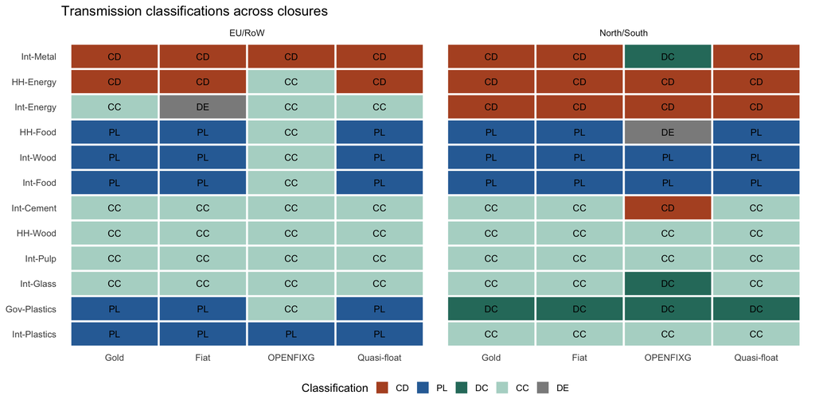

Current classification (the tag’s read-out) by named intervention, closure and regional setup. Rows follow the leaf order of the twelve-profile Ward tree. The inherited FIC label is a fitted classification convention, not independent evidence of an energy-trade mechanism.

The heatmap shows each closure’s classification against its own baseline. Against gold, OPENFIXG changes 8 of the 24 broad labels across the two setups. The figure also shows branch changes within SC; identical broad labels can conceal different response magnitudes.

## What changes from the submitted paper?

There are two comparisons using the inherited submitted classification codes. In EU/RoW under gold, **2 of 11 comparable scenarios** differ from the submitted reference. Across the full revised grid, **25 of 88 comparable observations** differ. sc12 Int-Food has no submitted reference, so its eight runs are excluded from that comparison. This is not a set of 88 matched old-model reruns.

The following table compares archived submitted and current revised EU/RoW gold VA responses directly, using the inherited broad codes on both sides. Signs can change within SC because its weak-response branch allows either sign for the partner.

| Scenario | Submitted label | Current label | EU submitted (%) | EU current (%) | RoW submitted (%) | RoW current (%) |
| --- | --- | --- | --- | --- | --- | --- |
| HH-Food | PL | PL | -0.021407 | -0.044241 | 0.005630 | 0.031855 |
| HH-Energy | FIC | FIC | 0.026468 | 0.061448 | -0.009005 | -0.010801 |
| HH-Wood | SC | SC | -0.000451 | 0.001952 | 0.000040 | -0.000678 |
| Gov-Plastics | PL | PL | -0.020840 | -0.011812 | 0.005962 | 0.023615 |
| Int-Wood | SC | PL | 0.001018 | -0.021602 | 0.000338 | 0.012056 |
| Int-Pulp | SC | SC | -0.000803 | -0.002927 | 0.000199 | 0.001307 |
| Int-Plastics | PL | PL | -0.015025 | -0.024492 | 0.004988 | 0.015155 |
| Int-Metal | CD | CD | 0.050100 | 0.050797 | -0.012405 | -0.021379 |
| Int-Glass | SC | SC | 0.003727 | 0.001525 | -0.001032 | -0.000687 |
| Int-Cement | SC | SC | 0.002149 | -0.001277 | 0.000218 | 0.000862 |
| Int-Energy | FIC | SC | 0.044820 | 0.142524 | -0.016818 | 0.001212 |

The submitted dendrogram used scaled EU−RoW divergence profiles for one model/configuration. The current profile tree uses joint regional responses across eight configurations with equal outcome-block weighting. Their branches are not directly comparable measures of model change: both the model and the clustering representation differ. The retained original submitted dendrogram is available in Analysis’s submitted ANOVA pages.

## Signed transmission labels

The inherited classification on 20261012_c79 applies the fixed threshold τ = 0.003% of region-2 baseline value added. Its SC code contains both the weak-response and both-contracting branches; the D-61 display maps these to CC and DC, maps FIC into CD, and maps UN into DE. The displayed five labels are descriptive response categories.

| Label | Observations |
| --- | --- |
| CD | 8 |
| FIC | 11 |
| PL | 27 |
| SC | 48 |
| UN | 2 |

The 96 current labels are classified on the high-finance, windowed grid. Numerical magnitudes and their decomposition come from the current tag. The quasi-float EU baseline retains the documented debt-slope exception, so acceptance of these observations is not a strict-stationarity or attraction claim.

## Sources and related analyses

Current tables are read from `transmission_structure_<tag>/` and `transmission_regime_grid_<tag>/`, selected by `data/current_results.json`. The calculations are implemented in `R/scenarios/transmission_cluster_structure.R` and `R/scenarios/classify_transmission_grid.R`.

The Analysis section also retains the submitted-scenario cross-border ANOVA, its construction-excluded variant, and the dated pre-recalibration revised-grid analysis. Those are separate experiments. Documentation contains the calibration comparison and diagnostic reports; Discussion explains what the current evidence supports and what remains an author decision.